# Finding Comparable Games

Phil Henrickson

2021-12-09

## What is this analysis?

This notebook is for selecting a game and identifying **its most comparable games using data from boardgamegeek.com**. I use a dimension reduction method (PCA) to learn the main points of variation in data about games from boardgamegeek. This gives me a vector with every game’s value on each of the principal components. To find similar games, I compute the distance between all games using the first ten principal components to compute their similarity. I compute the Manhattan distance (the sum of the absolute differences between two vectors) between all games in order to find games that are similar - that have the shortest distance between them.

Games that have similar data, such as the same mechanics, complexity, and playtime, will have shorter distances to each other than games that are very different. A game’s *neighbors* are its fellow games that have the shortest distance between then based on the observe data. This document displays a game’s 25 nearest neighbors and illustrate some of the dimensions that make the games similar.

## Game Profile: **Champions of Midgard**

Summary information for the selected game.

| ID | Game | Published | Player Count | Playing Time | UserRatings | Average | GeekAverage | Complexity |
| --- | --- | --- | --- | --- | --- | --- | --- | --- |
| 172287 | Champions of Midgard | 2015 | 2-4 | 90 min | 14,442 | 7.76 | 7.49 | 2.59 |

For the full profile of the selected game, go to https://boardgamegeek.com/boardgame/172287

## Most Similar Games to **Champions of Midgard**

The table below displays the most similar games to Champions of Midgard using data from boardgamegeek (BGG). The reported similarity score is the (squared) inverse of the Manhattan distance between two games.

**Note:** The analysis does not make use of a game’s number of ratings, average, or geek average, but instead looks only at a game’s categories, mechanics, playing time, player count, and complexity. The current approach for computing the distance weighs each component equally; I plan to explore a change to this in the future by using different measures of distance, as we would reasonably expect some components to be more important than others. I initially relied on Euclidean distance, but in tinkering with the results I have opted to go with the Manhattan distance for now.

| Rank | Similarity | Published | ID | Neighbor | BGGRating | GeekRating | Complexity |
| --- | --- | --- | --- | --- | --- | --- | --- |
| 1 | 32.75 | 2011 | 97875 | Wiraqocha | 6.57 | 5.74 | 2.67 |
| 2 | 29.27 | 2014 | 162580 | Realm of Wonder | 6.02 | 5.58 | 2.19 |
| 3 | 28.38 | 2019 | 181819 | Sorcerer | 7.77 | 6.22 | 2.88 |
| 4 | 28.32 | 2016 | 170223 | Centauri Saga | 6.60 | 5.66 | 2.94 |
| 5 | 28.29 | 2013 | 109215 | Gunship: First Strike! | 5.88 | 5.53 | 2.42 |
| 6 | 28.21 | 2017 | 201921 | Tiny Epic Quest | 7.03 | 6.66 | 2.66 |
| 7 | 28.12 | 2009 | 43443 | Castle Panic | 6.65 | 6.49 | 1.66 |
| 8 | 28.10 | 2018 | 209001 | Monster Lands | 7.27 | 6.19 | 3.34 |
| 9 | 27.66 | 2015 | 155708 | Tiny Epic Defenders | 6.28 | 5.96 | 1.81 |
| 10 | 27.54 | 2007 | 30804 | Song of Blades and Heroes: Revised Edition | 7.77 | 5.88 | 2.22 |
| 11 | 27.53 | 2021 | 342848 | World of Warcraft: Wrath of the Lich King | 7.82 | 5.76 | 2.18 |
| 12 | 27.35 | 2013 | 98960 | Rogue Agent | 5.73 | 5.52 | 2.29 |
| 13 | 27.32 | 2010 | 71906 | Castaways | 6.97 | 6.21 | 3.01 |
| 14 | 27.31 | 2021 | 246862 | Galaxy Hunters | 7.49 | 5.61 | 2.67 |
| 15 | 27.29 | 2021 | 258135 | Wild Assent | 7.32 | 5.58 | 2.67 |
| 16 | 27.22 | 2018 | 205477 | Vengeance | 7.14 | 5.88 | 2.84 |
| 17 | 26.80 | 2003 | 2611 | The HellGame | 6.52 | 5.65 | 3.67 |
| 18 | 26.79 | 2010 | 71721 | Space Hulk: Death Angel – The Card Game | 7.00 | 6.77 | 2.42 |
| 19 | 26.72 | 2016 | 181176 | Council of Blackthorn | 7.32 | 5.74 | 2.36 |
| 20 | 26.67 | 2013 | 128442 | Relic | 6.77 | 6.24 | 2.49 |
| 21 | 26.59 | 2015 | 163602 | XCOM: The Board Game | 7.04 | 6.73 | 2.90 |
| 22 | 26.48 | 2019 | 258148 | Power Rangers: Heroes of the Grid | 8.06 | 5.98 | 2.73 |
| 23 | 26.45 | 2019 | 276830 | Sanctum | 7.16 | 6.26 | 2.36 |
| 24 | 26.43 | 2017 | 220792 | The Expanse Board Game | 7.20 | 6.27 | 2.69 |
| 25 | 26.43 | 2017 | 209538 | Alexandria | 5.69 | 5.53 | 2.40 |

## Plotting Comparable Games to **Champions of Midgard**

Placing the selected game and its nearest neighbors on the first two principal components.

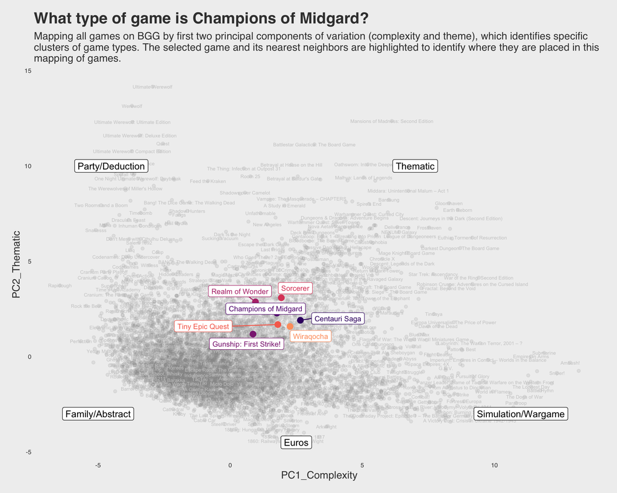

Placing games on the first four principal components, which I have found to loosely map to complexity, theme, economy, and cooperation.

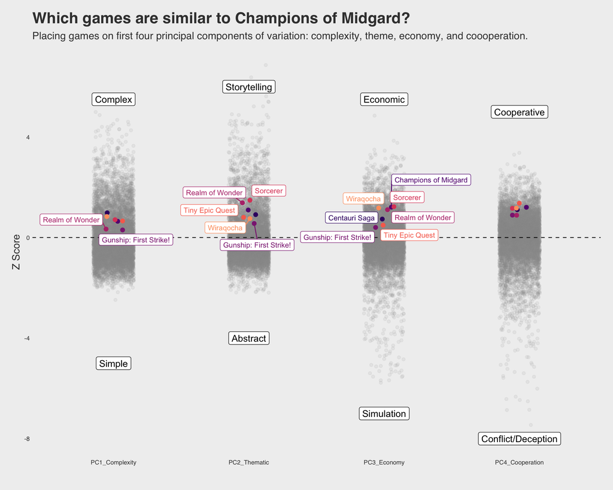